# Taller 1 - Exploración de Datos

### 1.2.2 Tabla de frecuencias cruzada entre Educational_Level y Gender

```r
# Tabla de frecuencias cruzada
freq_cruzada <- table(dt$Gender, dt$Education_Level)
freq_cruzada
```

```
##
##     College Doctorate Graduate High School Post-Graduate Uneducated Unknown
##   F     532       257     1670        1028           263        796     812
##   M     481       194     1458         985           253        691     707
```

```r
# Porcentaje por filas (genero)
prop_filas <- round(prop.table(freq_cruzada, margin = 1) * 100, 2)
prop_filas
```

```
##
##     College Doctorate Graduate High School Post-Graduate Uneducated Unknown
##   F    9.93      4.80    31.17       19.19          4.91      14.86   15.15
##   M   10.09      4.07    30.57       20.65          5.31      14.49   14.82
```

```r
# Porcentaje por columnas (nivel educativo)
prop_columnas <- round(prop.table(freq_cruzada, margin = 2) * 100, 2)
prop_columnas
```

```
##
##     College Doctorate Graduate High School Post-Graduate Uneducated Unknown
##   F   52.52     56.98    53.39       51.07         50.97      53.53   53.46
##   M   47.48     43.02    46.61       48.93         49.03      46.47   46.54
```

La tabla cruzada entre `Gender` y `Education_Level` permite observar cómo se distribuyen los clientes según su género en cada nivel educativo. Si se analiza por filas, se compara la composición educativa dentro de cada género; si se analiza por columnas, se compara la distribución de género dentro de cada nivel educativo. Esto ayuda a identificar si existe alguna relación entre el nivel educativo y el género de los clientes.

### 1.2.3 Desviación estándar de Credit_Limit

```r
desviacion_credit <- sd(dt$Credit_Limit, na.rm = TRUE)
desviacion_credit
```

```
## [1] 9088.777
```

La desviación estándar de `Credit_Limit` mide la dispersión de los valores alrededor de la media. Si la desviación es alta, significa que los límites de crédito presentan mucha variabilidad entre los clientes; si es baja, los valores están más concentrados alrededor del promedio. En este caso, la desviación estándar indica la extensión de la variabilidad en los límites de crédito de la base de datos.

### 1.2.4 Histogramas para Credit_Limit, Customer_Age y Avg_Open_To_Buy

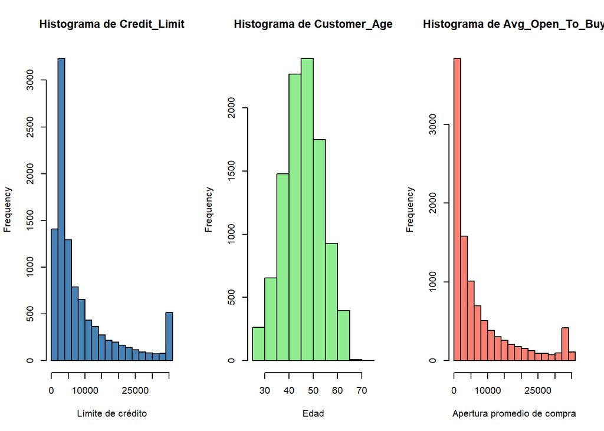

```r
par(mfrow = c(1, 3))

hist(dt$Credit_Limit,
     main = "Histograma de Credit_Limit",
     xlab = "Límite de crédito",
     col = "steelblue",
     border = "black")

hist(dt$Customer_Age,
     main = "Histograma de Customer_Age",
     xlab = "Edad",
     col = "lightgreen",
     border = "black")

hist(dt$Avg_Open_To_Buy,
     main = "Histograma de Avg_Open_To_Buy",
     xlab = "Apertura promedio de compra",
     col = "salmon",
     border = "black")
```

Los histogramas permiten visualizar la forma de la distribución de las variables cuantitativas. `Credit_Limit` muestra cómo se distribuyen los límites de crédito entre los clientes, `Customer_Age` refleja la concentración de las edades y `Avg_Open_To_Buy` evidencia si la apertura promedio de compra está sesgada o presenta valores atípicos. Este tipo de gráficas resulta útil para identificar patrones, asimetrías y valores extremos.

### 1.2.5 Probabilidad de cada nivel educativo

```r
# Frecuencia de cada nivel educativo
freq_edu <- table(dt$Education_Level)
freq_edu
```

```
##
##       College     Doctorate      Graduate   High School Post-Graduate
##          1013           451          3128          2013           516
##    Uneducated       Unknown
##          1487          1519
```

```r
# Probabilidad de cada nivel educativo
prob_edu <- round(prop.table(freq_edu) * 100, 2)
prob_edu
```

```
##
##       College     Doctorate      Graduate   High School Post-Graduate
##         10.00          4.45         30.89         19.88          5.10
##    Uneducated       Unknown
##         14.68         15.00
```

La probabilidad de cada nivel educativo se obtiene dividiendo la frecuencia de cada categoría entre el total de clientes. Esto permite identificar qué tan frecuente es cada nivel educativo dentro de la base de datos. Un nivel educativo con mayor probabilidad indica que es más predominante entre los clientes, mientras que uno con menor probabilidad aparece con menor frecuencia.

## 1.3 Conclusión general

En general, la base de datos presenta una muestra de clientes con diferentes edades, niveles educativos y límites de crédito. Las medidas descriptivas muestran que la variable `Customer_Age` se concentra alrededor de los 46 años, mientras que `Credit_Limit` y `Avg_Open_To_Buy` presentan una mayor variabilidad y evidencia de valores altos. Además, la distribución por género y nivel educativo permite describir la composición de la muestra de forma más detallada. Los histogramas complementan este análisis mostrando la forma de las distribuciones y ayudando a identificar sesgos o valores extremos.